# IMT 573 - Problem Set 3 - Working With Data Part 1

### Instructions

Before beginning this assignment, please ensure you have access to a working instance of Jupyter Notebooks with Python 3.

1. First, replace the “YOUR NAME HERE” text in the next cell with your own full name. Any collaborators must also be listed in this cell.
2. Be sure to include well-documented (e.g. commented) code cells, figures, and clearly written text explanations as necessary. Any figures should be clearly labeled and appropriately referenced within the text. Be sure that each visualization adds value to your written explanation; avoid redundancy – you do no need four different visualizations of the same pattern.
3. Collaboration on problem sets and labs is fun, useful, and encouraged. However, each student must turn in an individual write-up in their own words as well as code/work that is their own. Regardless of whether you work with others, what you turn in must be your own work; this includes code and interpretation of results. The names of all collaborators must be listed on each assignment. Do not copy-and-paste from other students’ responses or code - your code should never be on any other student's screen or machine.
4. All materials and resources that you use (with the exception of lecture slides) must be appropriately referenced within your assignment.
5. Partial credit will be awarded for each question for which a serious attempt at finding an answer has been shown. Students are *strongly* encouraged to attempt each question and document their reasoning process even if they cannot find the correct answer.
6. After completing the assignment, ensure that your code can run from start to finish without issue. Restart the kernal and run all cells to double check.

Name: Pratiibh Bassi

Collaborators:

For this assignment, you'll need (at least) the following packages. If the package does not load, be sure it is properly installed.

```python
import pandas as pd
import seaborn as sns
import matplotlib.pyplot as plt
```

In this problem set, we will continue to use data on animals at shelters in the city of [Long Beach, California](https://en.wikipedia.org/wiki/Long_Beach,_California) that we used in the previous problem set. The data can be found in the `animal_intakes_and_outcomes.csv` file. You can find more information on this data here.

### Problem 1: Describing the animal shelter data

Load the animal sheter data in and ensure you know the variables in the data. Keep the documentation of the dataset nearby.

```python
data = pd.read_csv("../Downloads/animal-shelter-intakes-and-outcomes-1.csv")
```

```python
data.describe()
```

|  | Age | was_outcome_alive |
| --- | --- | --- |
| count | 34863.000000 | 39886.000000 |
| mean | 5.408714 | 0.791004 |
| std | 3.882323 | 0.406596 |
| min | -7.000000 | 0.000000 |
| 25% | 3.000000 | 1.000000 |
| 50% | 5.000000 | 1.000000 |
| 75% | 7.000000 | 1.000000 |
| max | 55.000000 | 1.000000 |

```python
data
```

|  | Animal ID | Animal Name | Animal Type | Primary Color | Secondary Color | Sex | DOB | Age | Intake Date | Intake Condition | Intake Type | Intake Subtype | Reason for Intake | Outcome Date | Crossing | Jurisdiction | Outcome Type | Outcome Subtype | intake_is_dead | outcome_is_dead | was_outcome_alive |
| --- | --- | --- | --- | --- | --- | --- | --- | --- | --- | --- | --- | --- | --- | --- | --- | --- | --- | --- | --- | --- | --- |
| 0 | A002500 | PENELOPE | DOG | WHITE | NaN | Spayed | 2008-12-09 | 14.0 | 2017-07-02 | NORMAL | CONFISCATE | POLICE | NaN | 2017-07-03 | 4600 E OCEAN BLVD, LONG BEACH, CA 90803 | LONG BEACH | RETURN TO OWNER | FRE RID HM | Alive on Intake | False | 1 |
| 1 | A226033 | SNOOPY | DOG | WHITE | NaN | Neutered | 2002-02-23 | 21.0 | 2017-10-08 | NORMAL | STRAY | OTC | NaN | 2017-10-08 | 13200 BLK ACORO PL, CERRITOS, CA 90703 | CERRITOS | RETURN TO OWNER | FRE RID HM | Alive on Intake | False | 1 |
| 2 | A234250 | NINA | DOG | BR BRINDLE | NaN | Spayed | 2008-08-01 | 15.0 | 2018-06-01 | ILL SEVERE | CONFISCATE | CRUELTY | NaN | 2018-06-07 | 1900 W BURNETT ST, LONG BEACH, CA 90810 | LONG BEACH | EUTHANASIA | ILL SEVERE | Alive on Intake | True | 0 |
| 3 | A238953 | CECE | DOG | BUFF | NaN | Female | 2013-07-17 | 10.0 | 2017-01-03 | NORMAL | STRAY | FIELD | NaN | 2017-01-03 | 400 E HULLET ST, LONG BEACH, CA 90805 | LONG BEACH | RETURN TO OWNER | FRE RID HM | Alive on Intake | False | 1 |
| 4 | A242600 | BARBY | DOG | BLACK | NaN | Spayed | 2007-10-27 | 15.0 | 2020-11-18 | NORMAL | OWNER SURRENDER | OTC | NaN | 2020-11-19 | 2000 BLK W COWLES ST, LONG BEACH, CA 90813 | LONG BEACH | RESCUE | LIVELOVE | Alive on Intake | False | 1 |
| ... | ... | ... | ... | ... | ... | ... | ... | ... | ... | ... | ... | ... | ... | ... | ... | ... | ... | ... | ... | ... | ... |
| 39881 | A707543 | GEORGIE (PUP4) | DOG | TAN | NaN | Male | 2023-08-10 | 0.0 | 2023-09-24 | UNDER AGE/WEIGHT | STRAY | OTC | NaN | NaN | NaN | LONG BEACH | NaN | NaN | Alive on Intake | False | 1 |
| 39882 | A707556 | *VENTI | CAT | GRAY TABBY | NaN | Male | 2023-07-31 | 0.0 | 2023-09-24 | UNDER AGE/WEIGHT | STRAY | OTC | NaN | NaN | 900 BLK E SPRING STREET SIGNAL HILL CA 90755 | SIGNAL HILL | NaN | NaN | Alive on Intake | False | 1 |
| 39883 | A707578 | *SNOW | CAT | WHITE | NaN | Female | 2023-08-13 | 0.0 | 2023-09-24 | UNDER AGE/WEIGHT | STRAY | OTC | NaN | NaN | 100 BLK MIRA MAR AVE LONG BEACH CA 90803 | LONG BEACH | NaN | NaN | Alive on Intake | False | 1 |
| 39884 | A707580 | *OREO | CAT | BLACK | WHITE | Male | 2023-08-24 | 0.0 | 2023-09-24 | UNDER AGE/WEIGHT | STRAY | OTC | NaN | NaN | 600 BLOCK PIER D, LONG BEACH CA | LONG BEACH | NaN | NaN | Alive on Intake | False | 1 |
| 39885 | A707606 | *LOLA | DOG | BLACK | BROWN | Female | 2023-05-24 | 0.0 | 2023-09-24 | NORMAL | WELFARE SEIZED | POLICE | NaN | NaN | 1880 SANTA FE AVE | LONG BEACH | NaN | NaN | Alive on Intake | False | 1 |

39886 rows × 21 columns

```python
pd.set_option('display.max_columns', None)
```

```python
data.info()
```

```
<class 'pandas.core.frame.DataFrame'>
RangeIndex: 39886 entries, 0 to 39885
Data columns (total 21 columns):
 #   Column             Non-Null Count  Dtype
---  ------             --------------  -----
 0   Animal ID          39886 non-null  object
 1   Animal Name        22761 non-null  object
 2   Animal Type        39886 non-null  object
 3   Primary Color      39886 non-null  object
 4   Secondary Color    19015 non-null  object
 5   Sex                39886 non-null  object
 6   DOB                34863 non-null  object
 7   Age                34863 non-null  float64
 8   Intake Date        39886 non-null  object
 9   Intake Condition   39886 non-null  object
 10  Intake Type        39886 non-null  object
 11  Intake Subtype     39413 non-null  object
 12  Reason for Intake  2765 non-null   object
 13  Outcome Date       39285 non-null  object
 14  Crossing           39767 non-null  object
 15  Jurisdiction       39885 non-null  object
 16  Outcome Type       39282 non-null  object
 17  Outcome Subtype    35045 non-null  object
 18  intake_is_dead     39886 non-null  object
 19  outcome_is_dead    39886 non-null  bool
 20  was_outcome_alive  39886 non-null  int64
dtypes: bool(1), float64(1), int64(1), object(18)
memory usage: 6.1+ MB
```

```python
data.describe()
```

|  | Age | was_outcome_alive |
| --- | --- | --- |
| count | 34863.000000 | 39886.000000 |
| mean | 5.408714 | 0.791004 |
| std | 3.882323 | 0.406596 |
| min | -7.000000 | 0.000000 |
| 25% | 3.000000 | 1.000000 |
| 50% | 5.000000 | 1.000000 |
| 75% | 7.000000 | 1.000000 |
| max | 55.000000 | 1.000000 |

```python
data.dtypes
```

```
Animal ID             object
Animal Name           object
Animal Type           object
Primary Color         object
Secondary Color       object
Sex                   object
DOB                   object
Age                  float64
Intake Date           object
Intake Condition      object
Intake Type           object
Intake Subtype        object
Reason for Intake     object
Outcome Date          object
Crossing              object
Jurisdiction          object
Outcome Type          object
Outcome Subtype       object
intake_is_dead        object
outcome_is_dead         bool
was_outcome_alive      int64
dtype: object
```

```python
data["Animal Type"].value_counts()
```

```
Animal Type
CAT           18877
DOG           12747
BIRD           2919
WILD           1958
OTHER          1954
RABBIT          710
REPTILE         464
GUINEA PIG      242
LIVESTOCK        12
AMPHIBIAN         3
Name: count, dtype: int64
```

```python
data["Intake Date"].min()
```

```
'2017-01-01'
```

```python
data["Intake Date"].max()
```

```
'2023-09-27'
```

```python
data.loc[(data["Animal Type"] == "CAT") & (data['Primary Color'] == 'BLACK') & (data['Jurisdiction'] == 'LOS ALAMITOS') & (data['Age'] < 3)]
```

|  | Animal ID | Animal Name | Animal Type | Primary Color | Secondary Color | Sex | DOB | Age | Intake Date | Intake Condition | ... | Intake Subtype | Reason for Intake | Outcome Date | Crossing | Jurisdiction | Outcome Type | Outcome Subtype | intake_is_dead | outcome_is_dead | was_outcome_alive |
| --- | --- | --- | --- | --- | --- | --- | --- | --- | --- | --- | --- | --- | --- | --- | --- | --- | --- | --- | --- | --- | --- |
| 4325 | A656207 | *MISSY | CAT | BLACK | NaN | Spayed | 2021-03-12 | 2.0 | 2021-04-12 | UNDER AGE/WEIGHT | ... | FIELD | NaN | 2022-04-13 | 3500 THOR AVE, LOS ALAMITOS, CA 90720 | LOS ALAMITOS | ADOPTION | WEB | Alive on Intake | False | 1 |
| 5327 | A677720 | ONYX | CAT | BLACK | NaN | Spayed | 2022-04-15 | 1.0 | 2022-06-15 | UNDER AGE/WEIGHT | ... | OTC | NaN | 2022-07-27 | 33600 BLK HOWARD AVE, LOS ALAMITOS, CA 90720 | LOS ALAMITOS | HOMEFIRST | NaN | Alive on Intake | False | 1 |
| 12012 | A677722 | *MICAH | CAT | BLACK | WHITE | Neutered | 2022-04-15 | 1.0 | 2022-06-15 | UNDER AGE/WEIGHT | ... | OTC | NaN | 2022-08-03 | 33600 BLK HOWARD AVE, LOS ALAMITOS, CA 90720 | LOS ALAMITOS | TRANSFER | SPCALA | Alive on Intake | False | 1 |
| 18708 | A678721 | *ASTER | CAT | BLACK | NaN | Female | 2022-06-18 | 1.0 | 2022-07-01 | NORMAL | ... | OTC | NaN | 2022-08-06 | 11300 BLK LOS ALAMITOS BLVD, LOS ALAMITOS, CA ... | LOS ALAMITOS | HOMEFIRST | NaN | Alive on Intake | False | 1 |
| 19627 | A700185 | *EMBER | CAT | BLACK | NaN | Female | 2023-04-04 | 0.0 | 2023-06-04 | NORMAL | ... | OTC | NaN | 2023-06-16 | 3600 BLK GREEN AVE, LOS ALAMITOS, CA 90720 | LOS ALAMITOS | TRANSFER | SPCALA | Alive on Intake | False | 1 |
| 19686 | A701237 | *TUCKER | CAT | BLACK | WHITE | Neutered | 2023-05-02 | 0.0 | 2023-06-20 | UNDER AGE/WEIGHT | ... | OTC | NaN | 2023-08-30 | 11000 BLK DAVENPORT ROAD | LOS ALAMITOS | ADOPTION | WEB | Alive on Intake | False | 1 |
| 25291 | A677721 | WYBIE | CAT | BLACK | WHITE | Neutered | 2022-04-15 | 1.0 | 2022-06-15 | UNDER AGE/WEIGHT | ... | OTC | NaN | 2022-07-17 | 3600 BLK HOWARD AVE, LOS ALAMITOS, CA 90720 | LOS ALAMITOS | ADOPTION | WEB | Alive on Intake | False | 1 |
| 25348 | A678719 | *ARROW | CAT | BLACK | NaN | Male | 2022-06-18 | 1.0 | 2022-07-01 | NORMAL | ... | OTC | NaN | 2022-08-11 | 11300 BLK LOS ALAMITOS BLVD, LOS ALAMITOS, CA ... | LOS ALAMITOS | RESCUE | CATPAWS | Alive on Intake | False | 1 |
| 31967 | A677719 | *MAIA | CAT | BLACK | NaN | Spayed | 2022-04-15 | 1.0 | 2022-06-15 | UNDER AGE/WEIGHT | ... | OTC | NaN | 2022-08-03 | 3600 BLK HOWARD AVE, LOS ALAMITOS, CA 90720 | LOS ALAMITOS | TRANSFER | SPCALA | Alive on Intake | False | 1 |
| 32918 | A700183 | *FIREWALL | CAT | BLACK | NaN | Male | 2023-04-04 | 0.0 | 2023-06-04 | NORMAL | ... | OTC | NaN | 2023-06-16 | 3600 BLK GREEN AVE, LOS ALAMITOS, CA 90720 | LOS ALAMITOS | TRANSFER | SPCALA | Alive on Intake | False | 1 |
| 33199 | A705321 | NaN | CAT | BLACK | NaN | Unknown | 2023-08-07 | 0.0 | 2023-08-23 | UNDER AGE/WEIGHT | ... | OTC | NaN | 2023-08-25 | 12100 BLK MONTECITO ROAD LOS ALAMITOS CA 90720 | LOS ALAMITOS | RESCUE | FOUND ANIM | Alive on Intake | False | 1 |
| 38628 | A678720 | *ASHTON | CAT | BLACK | NaN | Male | 2022-06-18 | 1.0 | 2022-07-01 | NORMAL | ... | OTC | NaN | 2022-08-11 | 11300 BLK LOS ALAMITOS BLVD, LOS ALAMITOS, CA ... | LOS ALAMITOS | RESCUE | CATPAWS | Alive on Intake | False | 1 |
| 38663 | A679653 | *BART | CAT | BLACK | NaN | Neutered | 2022-05-13 | 1.0 | 2022-07-13 | INJURED MILD | ... | OTC | NaN | 2022-09-25 | 10500 BLK BLOOMFIELD ST, LOS ALAMITOS, CA 90720 | LOS ALAMITOS | ADOPTION | WEB | Alive on Intake | False | 1 |
| 38939 | A687211 | *JUNO | CAT | BLACK | NaN | Female | 2022-04-20 | 1.0 | 2022-10-20 | INJURED SEVERE | ... | OTC | NaN | 2022-10-20 | 30 BLK W. CERRITOS AVE, LOS ALAMITOS, CA 90720 | LOS ALAMITOS | EUTHANASIA | ILL SEVERE | Alive on Intake | True | 0 |
| 39433 | A699288 | NaN | CAT | BLACK | NaN | Male | 2023-04-24 | 0.0 | 2023-05-24 | NORMAL | ... | OTC | NaN | 2023-05-26 | 11900 BLK MONTECITO RD LOS AL 90720 | LOS ALAMITOS | RESCUE | LITTLEPAWS | Alive on Intake | False | 1 |
| 39476 | A700184 | *ERIN | CAT | BLACK | NaN | Female | 2023-04-04 | 0.0 | 2023-06-04 | NORMAL | ... | OTC | NaN | 2023-06-10 | 3600 BLK GREEN AVE, LOS ALAMITOS, CA 90720 | LOS ALAMITOS | HOMEFIRST | NaN | Alive on Intake | False | 1 |

16 rows × 21 columns

```python
[data['Primary Color'].mode(), data['Secondary Color'].mode()]
```

```
[0    BLACK
 Name: Primary Color, dtype: object,
 0    WHITE
 Name: Secondary Color, dtype: object]
```

```python
data['Animal ID'].nunique()
```

```
38554
```

#### (a) Describe and summarize

Answer the following questions to describe and summarize the data:

- How many records are in the data?
- How many unique animals are in the data?
- How many types of animals are included in the data? What types are these?
- Across how many years does the data span? What are the years?
- How many primarily black cats less than 3 years of age were found in Los Alamitos?
- What is the most common primary/secondary color combination in the data (consider only when both colors are listed)?

#### (b) Reflect and question

Comment on the questions (and answers) so far. Were you able to answer all of these questions? Are all questions well defined? Is the data good enough to answer all these?

I was able to answer all these questions, although a bit of the questions were confusing. Unique animals versus different types of animals, whats the difference? And it was quite a bit tricky to try to pull only the results of animals that have both two colors, and to find what is most common for both colors to be only if both a primary and secondary color is left.

### Problem 2: Animal ages

#### (a) Typical ages

What is the typical age of animals in the data?

```python
data["Age"].mode()
```

```
0    6.0
Name: Age, dtype: float64
```

The typical age of animals in the data is 6 years old

#### (b) Defining ages

What definition of "typical age" did you use to answer part (a)? Did you look at ages by animal type? Did you do any specific exploration and description of this variable prior to using it? If not, please do so now. Is there any missing data? Are there any implausible or invalid entries?

My definition of typical age was just the age of any and all animals in the dataset. I looked for the most repeated age in the group, regardless of animal as the question asked the typical age of all animals in the data.

#### (c) Ages by jurisdiction

Now compute typical animal age by jurisdiction. Which three jurisdictions have the highest animal age? Be sure to justify you choice of age calculation and animal/jurisdiction grouping(s).

```python
data.loc[(data["Jurisdiction"] == "LONG BEACH", "Age")].value_counts()
```

```
Age
 6.0     4259
 5.0     3646
 4.0     3557
 1.0     2640
 3.0     2631
 2.0     2409
 0.0     2190
 7.0     2082
 8.0     1596
 9.0     1286
 10.0     899
 11.0     686
 12.0     541
 13.0     445
 14.0     391
 15.0     259
 16.0     245
 17.0     150
 18.0     107
 19.0      65
 20.0      46
 21.0      23
 22.0      18
 23.0      11
 24.0       5
 25.0       4
 30.0       2
 26.0       1
 55.0       1
-7.0        1
Name: count, dtype: int64
```

```python
data.loc[data["Age"].idxmax()]
```

```
Animal ID                                            A600476
Animal Name                                           MRS. T
Animal Type                                          REPTILE
Primary Color                                          BROWN
Secondary Color                                          NaN
Sex                                                   Female
DOB                                               1967-11-26
Age                                                     55.0
Intake Date                                       2017-11-26
Intake Condition                                      NORMAL
Intake Type                                        SAFE KEEP
Intake Subtype                                    OWNER DIED
Reason for Intake                                        NaN
Outcome Date                                      2017-11-29
Crossing             2300 BLK PARK AVE, LONG BEACH, CA 90815
Jurisdiction                                      LONG BEACH
Outcome Type                                 RETURN TO OWNER
Outcome Subtype                                       WALKIN
intake_is_dead                               Alive on Intake
outcome_is_dead                                        False
was_outcome_alive                                          1
Name: 8022, dtype: object
```

```python
data1=data[['Jurisdiction']][data.Age == data['Age'].max()]
data1
```

|  | Jurisdiction |
| --- | --- |
| 8022 | LONG BEACH |

```python
data.loc[data['Age'].nlargest(10).index]
```

|  | Animal ID | Animal Name | Animal Type | Primary Color | Secondary Color | Sex | DOB | Age | Intake Date | Intake Condition | ... | Intake Subtype | Reason for Intake | Outcome Date | Crossing | Jurisdiction | Outcome Type | Outcome Subtype | intake_is_dead | outcome_is_dead | was_outcome_alive |
| --- | --- | --- | --- | --- | --- | --- | --- | --- | --- | --- | --- | --- | --- | --- | --- | --- | --- | --- | --- | --- | --- |
| 8022 | A600476 | MRS. T | REPTILE | BROWN | NaN | Female | 1967-11-26 | 55.0 | 2017-11-26 | NORMAL | ... | OWNER DIED | NaN | 2017-11-29 | 2300 BLK PARK AVE, LONG BEACH, CA 90815 | LONG BEACH | RETURN TO OWNER | WALKIN | Alive on Intake | False | 1 |
| 13248 | A706980 | NaN | REPTILE | GREEN | BROWN | Male | 1993-09-15 | 30.0 | 2023-09-15 | NORMAL | ... | FIELD | NaN | 2023-09-19 | 5300 E WALTON ST, LONG BEACH, CA 90815 | LONG BEACH | RESCUE | NaN | Alive on Intake | False | 1 |
| 27323 | A590980 | STEVE | REPTILE | GREEN | BROWN | Male | 1993-05-28 | 30.0 | 2017-05-28 | NORMAL | ... | OTC | MOVE | 2017-05-30 | 4500 BLK MONTAIR AVE, LONG BEACH, CA 90808 | LONG BEACH | RESCUE | SC REPTILE | Alive on Intake | False | 1 |
| 28628 | A611828 | NaN | REPTILE | TAN | BROWN | Male | 1993-07-28 | 30.0 | 2018-07-28 | NORMAL | ... | OTC | NaN | 2018-08-02 | 19TH ST / JUNIPERO AVE, SIGNAL HILL, CA 90755 | SIGNAL HILL | ADOPTION | WALKIN | Alive on Intake | False | 1 |
| 33 | A382389 | BAILEY | DOG | BLACK | BROWN | Spayed | 1996-11-11 | 26.0 | 2017-01-07 | NORMAL | ... | FIELD | NaN | 2017-01-08 | 5300 BLK E ELIOT ST, LONG BEACH, CA 90803 | LONG BEACH | RETURN TO OWNER | MICROCHIP | Alive on Intake | False | 1 |
| 12397 | A688767 | *ROYAL | LIVESTOCK | GRAY | WHITE | Male | 1997-11-18 | 25.0 | 2022-11-15 | INJURED MILD | ... | ABAN FIELD | NaN | 2022-11-19 | 500 BLK E 72ND ST, LONG BEACH, CA 90805 | LONG BEACH | RESCUE | NaN | Alive on Intake | False | 1 |
| 20126 | A497047 | MEL VEL | DOG | WHITE | BROWN | Neutered | 1998-06-03 | 25.0 | 2017-10-27 | NORMAL | ... | FIELD | NaN | 2017-10-28 | 17100 JEANETTE AVE, CERRITOS, CA 90703 | CERRITOS | RETURN TO OWNER | PHONE | Alive on Intake | False | 1 |
| 21312 | A600024 | ROCKY | DOG | WHITE | NaN | Male | 1997-11-12 | 25.0 | 2018-10-17 | NORMAL | ... | OTC | MOVE | 2018-10-18 | 3200 DELTA AVE, LONG BEACH, CA 90810 | LONG BEACH | TRANSFER | SPCALA | Alive on Intake | False | 1 |
| 31576 | A669351 | AHI | CAT | TORTIE | NaN | Female | 1998-01-14 | 25.0 | 2022-01-14 | AGED | ... | FIELD | NaN | 2022-01-15 | 5800 E LOS SANTOS DR, LONG BEACH, CA 90815 | LONG BEACH | RETURN TO OWNER | WALKIN | Alive on Intake | False | 1 |
| 33396 | A471926 | OLE | CAT | BRN TABBY | NaN | Male | 1998-03-27 | 25.0 | 2019-11-12 | AGED | ... | FIELD | NaN | 2019-11-15 | 4700 E PACIFIC COAST HWY, LONG BEACH, CA 90804 | LONG BEACH | RETURN TO OWNER | WALKIN | Alive on Intake | False | 1 |

10 rows × 21 columns

#### (d) Intake seasonality

One may wonder whether intakes are in any way related to weather. We do not have weather information here but let’s analyze how intakes are related to seasons. Which seasons have the most intakes? Why might this be the case? In your communication of your analysis use one graphical visualization and one tabular respresentation of your findings.

```python
data_filtered = data.copy()
```

```python
data_filtered = data_filtered[data_filtered.Age >= 0]
```

```python
def get_season(date_string):
    month = int(date_string[5:7])
    season = "Autumn"
    if month in [12, 1, 2]:
        season = "Winter"
    elif month in [3, 4, 5]:
        season = "Spring"
    elif month in [6, 7, 8]:
        season = "Summer"
    return season
```

```python
data_filtered['Season'] = data_filtered['Intake Date'].apply(get_season)
```

```python
data_filtered['Season'].value_counts()
```

```
Season
Summer    11376
Spring     9992
Autumn     7855
Winter     5639
Name: count, dtype: int64
```

```python
tabulated = data_filtered.groupby(['Season', 'Animal Type'])['Animal ID'].count().unstack().fillna(0)
tabulated = round(tabulated / tabulated.sum() * 100, 2)
tabulated
```

| Animal Type Season | AMPHIBIAN | BIRD | CAT | DOG | GUINEA PIG | LIVESTOCK | OTHER | RABBIT | REPTILE | WILD |
| --- | --- | --- | --- | --- | --- | --- | --- | --- | --- | --- |
| Autumn | 0.0 | 24.52 | 22.86 | 22.69 | 24.29 | 41.67 | 16.41 | 20.95 | 24.64 | 18.01 |
| Spring | 0.0 | 29.68 | 29.57 | 25.15 | 20.90 | 8.33 | 43.85 | 31.16 | 27.96 | 40.46 |
| Summer | 0.0 | 32.00 | 36.10 | 28.54 | 19.21 | 25.00 | 29.90 | 31.87 | 29.38 | 26.89 |
| Winter | 100.0 | 13.80 | 11.47 | 23.62 | 35.59 | 25.00 | 9.85 | 16.02 | 18.01 | 14.65 |

```python
data_filtered['intake_year_month'] = data_filtered['Intake Date'].str.slice(0,7)
```

```python
data_grouped = data_filtered.groupby(['intake_year_month', 'Season'])['Animal ID'].count().reset_index()
xticks = data_grouped.intake_year_month.unique()
```

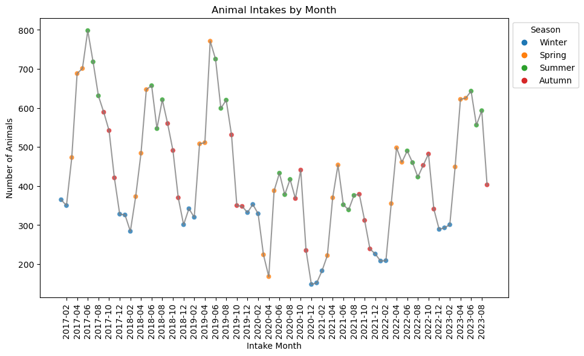

```python
plt.figure(figsize=(10,6))

fig = sns.lineplot(data = data_grouped, x = 'intake_year_month',
                  y = 'Animal ID', color = 'grey', alpha = 0.8);
fig = sns.scatterplot(data = data_grouped, x = 'intake_year_month',
                  y = 'Animal ID', hue = 'Season', alpha = 0.8);
plt.xticks(rotation=90);
fig.set_xticks(xticks[1::2]);
plt.ylabel('Number of Animals')
plt.xlabel('Intake Month')
plt.title('Animal Intakes by Month')
sns.move_legend(fig, "upper left", bbox_to_anchor=(1, 1))
```

Summer had much higher intake rates than other season and then a decline across Autumn before a lull in winter. Interestingly, intake numbers dropped drastically during COVID lockdown months and have been slower to recover since.

#### (e) Challenge your results

After completing the exploratory analyses from Problem 2, do you have any concerns about your findings? How well defined was your original question? Do you still believe this question can be answered using this dataset? Comment on any ethical and/or privacy concerns you have with your analysis.

In terms of results we find, assumptions and interpretations when examining associations between specific locales and animal ages may lead to incorrect conclusions drawn about these locales.

### Problem 3: Pets returned to owner in Long Beach

For this problem, only consider instances where the jurisdiction is Long Beach and the outcome is that the animal was returned to owner.

```python
data.loc[(data["Jurisdiction"] == "LONG BEACH") & (data['Outcome Type'] == 'RETURN TO OWNER')]
```

|  | Animal ID | Animal Name | Animal Type | Primary Color | Secondary Color | Sex | DOB | Age | Intake Date | Intake Condition | ... | Intake Subtype | Reason for Intake | Outcome Date | Crossing | Jurisdiction | Outcome Type | Outcome Subtype | intake_is_dead | outcome_is_dead | was_outcome_alive |
| --- | --- | --- | --- | --- | --- | --- | --- | --- | --- | --- | --- | --- | --- | --- | --- | --- | --- | --- | --- | --- | --- |
| 0 | A002500 | PENELOPE | DOG | WHITE | NaN | Spayed | 2008-12-09 | 14.0 | 2017-07-02 | NORMAL | ... | POLICE | NaN | 2017-07-03 | 4600 E OCEAN BLVD, LONG BEACH, CA 90803 | LONG BEACH | RETURN TO OWNER | FRE RID HM | Alive on Intake | False | 1 |
| 3 | A238953 | CECE | DOG | BUFF | NaN | Female | 2013-07-17 | 10.0 | 2017-01-03 | NORMAL | ... | FIELD | NaN | 2017-01-03 | 400 E HULLET ST, LONG BEACH, CA 90805 | LONG BEACH | RETURN TO OWNER | FRE RID HM | Alive on Intake | False | 1 |
| 6 | A282135 | WHISKEY | DOG | WHITE | NaN | Neutered | 2003-07-07 | 20.0 | 2021-02-06 | INJURED MILD | ... | FIELD | NaN | 2021-02-06 | 1830 E PACIFIC COAST HWY, LONG BEACH, CA 90806 | LONG BEACH | RETURN TO OWNER | MICROCHIP | Alive on Intake | False | 1 |
| 7 | A285440 | CHUIE | DOG | BROWN | NaN | Neutered | NaN | NaN | 2018-12-01 | NORMAL | ... | OTC | NaN | 2018-12-01 | 30TH ST / PINE AVE, LONG BEACH, CA 90806 | LONG BEACH | RETURN TO OWNER | WALKIN | Alive on Intake | False | 1 |
| 8 | A287459 | PADFOOT | DOG | BLACK | NaN | Neutered | 2009-02-09 | 14.0 | 2017-03-18 | NORMAL | ... | OTC | NaN | 2017-03-18 | E SPRING ST / CLARK AVE, LONG BEACH, CA 90815 | LONG BEACH | RETURN TO OWNER | PHONE | Alive on Intake | False | 1 |
| ... | ... | ... | ... | ... | ... | ... | ... | ... | ... | ... | ... | ... | ... | ... | ... | ... | ... | ... | ... | ... | ... |
| 39806 | A705763 | OSCAR | CAT | BRN TABBY | NaN | Male | 2020-08-30 | 3.0 | 2023-08-30 | ILL MILD | ... | FIELD | NaN | 2023-09-02 | 3100 BLK E ARTESIA BLVD, LB 90805 | LONG BEACH | RETURN TO OWNER | WALKIN | Alive on Intake | False | 1 |
| 39812 | A705849 | COCO | DOG | BROWN | NaN | Female | 2022-08-31 | 1.0 | 2023-08-31 | NORMAL | ... | OTC | NaN | 2023-08-31 | 2500 BLK CHESTNUT AVE LONG BEACH CA 90806 | LONG BEACH | RETURN TO OWNER | WALKIN | Alive on Intake | False | 1 |
| 39818 | A706177 | CARTER | DOG | WHITE | NaN | Neutered | 2020-09-03 | 3.0 | 2023-09-03 | NORMAL | ... | POLICE | NaN | 2023-09-06 | 3000 WOODRUFF AVE, LB 90808 | LONG BEACH | RETURN TO OWNER | WALKIN | Alive on Intake | False | 1 |
| 39841 | A706730 | GUTTA | DOG | BLACK | TAN | Male | 2020-09-13 | 3.0 | 2023-09-13 | NORMAL | ... | OTC | NaN | 2023-09-19 | 3500 BLOCK SANTA FE AVE, LONG BEACH CA | LONG BEACH | RETURN TO OWNER | FRE RID HM | Alive on Intake | False | 1 |
| 39861 | A707076 | ZELDA | DOG | BROWN | NaN | Female | 2019-09-21 | 4.0 | 2023-09-19 | NORMAL | ... | OWNER DIED | NaN | 2023-09-21 | 6744 ORIZABA AVE, LONG BEACH CA 90805 | LONG BEACH | RETURN TO OWNER | WALKIN | Alive on Intake | False | 1 |

3739 rows × 21 columns

#### (a) How many animals?

How many records are there from Long Beach where the animal was returned to owner?

We can see there are 3739 rows, meaning 3739 records where this condition is met.

#### (b) How many types of animals?

How many types of animals are in these records?

```python
data2 = data.loc[(data["Jurisdiction"] == "LONG BEACH") & (data['Outcome Type'] == 'RETURN TO OWNER')]

data2['Animal Type'].unique()
```

```
array(['DOG', 'CAT', 'BIRD', 'REPTILE', 'RABBIT', 'GUINEA PIG', 'OTHER',
       'WILD'], dtype=object)
```

```python
data2['Animal Type'].nunique()
```

```
8
```

As we can see, there are 8 unique type of animals in the list.

#### (c) Which types of animals?

Which types of animals are present in the entire data set that are not present when looking at instances where the jurisdiction is Long Beach and the outcome is that the animal was returned to owner?

The types of animals that aren't present in this jurisdiction that were returned to their owners are livestock and amphibians.

#### (d) How many of each type of animals?

How many unique animals (not records) are there for each animal from Long Beach where the animal was returned to owner?

```python
data2['Animal Type'].nunique()
```

```
8
```

#### (e) Decreases during COVID

Did all animal types see a decrease in intakes during 2020 compared to their pre-2020 annual average? Which animal types saw the largest numerical drop and the largest percent drop?

```python
data_prob_3 = data[(data['Jurisdiction'] == 'LONG BEACH') & (data['Outcome Type'] == 'RETURN TO OWNER')]
```

```python
data_prob_3['intake_year'] = data_prob_3['Intake Date'].str.slice(0, 4).astype(int)
```

```python
data_prob_3['intake_year']
```

```
0        2017
3        2017
6        2021
7        2018
8        2017
         ...
39806    2023
39812    2023
39818    2023
39841    2023
39861    2023
Name: intake_year, Length: 3739, dtype: int32
```

```python
pre_covid = data_prob_3[data_prob_3.intake_year < 2020].groupby(['Animal Type', 'intake_year'])['Animal ID'].count().reset_index()
pre_covid = pre_covid.groupby(['Animal Type'])['Animal ID'].mean()
pre_covid
```

```
Animal Type
BIRD         2.333333
CAT         64.333333
DOG        605.666667
RABBIT       1.333333
REPTILE      2.666667
WILD         1.000000
Name: Animal ID, dtype: float64
```

```python
mid_covid = data_prob_3[data_prob_3.intake_year == 2020].groupby(['Animal Type'])['Animal ID'].count()
mid_covid
```

```
Animal Type
BIRD         1
CAT         43
DOG        370
REPTILE      1
Name: Animal ID, dtype: int64
```

```python
diffs = pd.DataFrame(pre_covid)

diffs.columns = ['pre_2020']

diffs['2020'] = mid_covid

diffs = diffs.fillna(0)

diffs['diff'] = diffs['pre_2020'] - diffs['2020']

diffs['perc_drop'] = diffs['diff'] / diffs['pre_2020'] * 100

diffs
```

| Animal Type | pre_2020 | 2020 | diff | perc_drop |
| --- | --- | --- | --- | --- |
| BIRD | 2.333333 | 1.0 | 1.333333 | 57.142857 |
| CAT | 64.333333 | 43.0 | 21.333333 | 33.160622 |
| DOG | 605.666667 | 370.0 | 235.666667 | 38.910292 |
| RABBIT | 1.333333 | 0.0 | 1.333333 | 100.000000 |
| REPTILE | 2.666667 | 1.0 | 1.666667 | 62.500000 |
| WILD | 1.000000 | 0.0 | 1.000000 | 100.000000 |

#### (f) Reflect and Question

What are your thoughts on the questions (and answers) for problem 3? Were you able to answer all of these questions? Are all questions well-defined? Is the data good enough to answer all these?

Through deep analysis by splitting the dataset into two seperate columns of pre_2020 and 2020, we are able to answer all the questions, especially the one regarding COVID decreases. The questions are well-defined and require insight and planning a solution before shooting attempts at the answer. The data is good enough to be played with to find answers to the questions.